# Sofala Simple Spatial Survey Method (S3M)

Data Quality

Mark Myatt

Ernest Guevarra

2022-05-26 17:31:25

# 1. Summary: The Data Quality Scorecard (DQS)

Following is today’s data quality scorecard (DQS) for the endline survey anthropometric dataset.

| **Criteria** | **Fail Standard** | **Observed** | **Details** |
| --- | --- | --- | --- |
| Outliers | > 1% | Mother data - 8.3%; Child data - 0.9% | see 2.1. Mother anthropometry and 2.2. Child anthropometry |
| Illegal values | > 1% | Mother data - 8.3%; Child data - 0.9% | see 2.1. Mother anthropometry and 2.2. Child anthropometry |
| Flagged records | > 5% | 2.8% | see 2.2.2. Flagged records |
| Weight-for-age z-score | Markedly non-normal | Check WAZ Q-Q plot; Skewness = 0 (excellent); Kurtosis = 1 (problematic) | see 2.2.3. Distribution of anthropometric z-scores and MUAC |
| Height-for-age z-score | Markedly non-normal | Check HAZ Q-Q plot; Skewness = 0 (excellent); Kurtosis = 4 (problematic) | see 2.2.3. Distribution of anthropometric z-scores and MUAC |
| Weight-for-height z-score | Markedly non-normal; MAD > 1.2 or MAD < 0.8 | Check WHZ Q-Q plot; Skewness = 1 (problematic); Kurtosis = 12 (problematic); MAD = 1.09 | see 2.2.3. Distribution of anthropometric z-scores and MUAC; 2.2.4. Median absolute deviation of weight-for-height z-score |
| Digit preference - weight | DPS > 12 | DPS = 2.51 | see 2.2.5. Digit preference |
| Digit preference - height | DPS > 12 | DPS = 6.27 | see 2.2.5. Digit preference |
| Digit preference - MUAC | DPS > 12 | DPS = 4.12 | see 2.2.5. Digit preference |
| Age heaping | Marked age heaping | Marked age heaping at whole years (p = 0) | see 2.2.6. Age heaping |
| Sex ratio | p < 0.05 | p = 0.9375 | see 2.2.7. Sex ratio |
| Age ratio | p < 0.05 | p = 0.0708 | see 2.2.8. Age ratio |
| Age structure | Marked deviation from expected | Check age pyramid and age ratio test | See 2.2.8. Age ratio and 2.2.9. Age structure |

# 2. Anthropometric data checks

## 2.1. Mother anthropometry

### 2.1.1. Check range and legal values

#### Univariate outliers

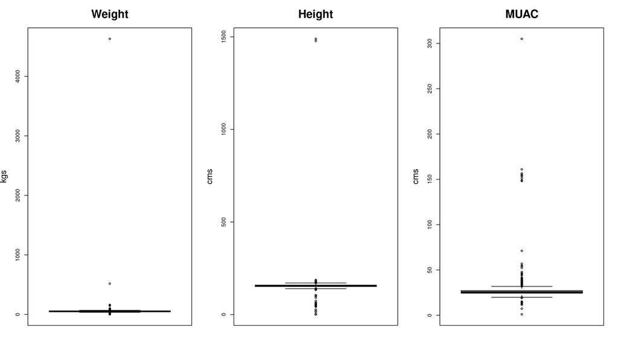

Number of outliers per measurement type

| Outlier type | Number of records |
| --- | --- |
| Weight outlier | 151 |
| Height outlier | 88 |
| MUAC outlier | 179 |

#### A total of **310** unique univariate outliers were found and are listed below. Potential outlier anthropometric measurements are in **BOLD RED**.

Outlier measurements - Mother

| Survey Date | Record ID | Survey Team | Enum Code | Weight (kgs) | Height (cms) | MUAC (cms) |
| --- | --- | --- | --- | --- | --- | --- |
| 2022-04-13 | 95732093 | 11 | 1103 | 71.4 | 157 | 30.5 |
| 2022-04-13 | 95992000 | 2 | 206 | 59.3 | 160 | 32.9 |
| 2022-04-14 | 95730982 | 2 | 206 | 88.4 | 169.5 | 32.7 |
| 2022-04-14 | 95731455 | 1 | 103 | 70.1 | 153.5 | 28.9 |
| 2022-04-14 | 95893788 | 12 | 1206 | 78.8 | 158 | 34.2 |
| 2022-04-14 | 95735902 | 1 | 101 | 62 | 15.5 | 29.4 |
| 2022-04-14 | 95774098 | 11 | 1101 | 50.3 | 1.51 | 26.9 |
| 2022-04-14 | 95774210 | 11 | 1101 | 46.5 | 1.52 | 25.1 |
| 2022-04-14 | 95774431 | 12 | 1205 | 48.2 | 48 | 23.2 |
| 2022-04-14 | 95731454 | 1 | 103 | 66.7 | 151.5 | 36.3 |
| 2022-04-15 | 95731871 | 10 | 1006 | 77.6 | 160.2 | 33.2 |
| 2022-04-15 | 95732078 | 9 | 901 | 73.4 | 162.2 | 31.6 |
| 2022-04-15 | 95732094 | 11 | 1103 | 80.6 | 150.5 | 40.7 |
| 2022-04-15 | 95734925 | 8 | 806 | 73 | 54.8 | 35 |
| 2022-04-15 | 95774432 | 12 | 1205 | 70.1 | 156 | 30 |
| 2022-04-15 | 95796800 | 11 | 1101 | 89 | 149 | 40.3 |
| 2022-04-15 | 95802966 | 14 | 1406 | 83.3 | 158.5 | 36.5 |
| 2022-04-15 | 95767982 | 7 | 701 | 55.4 | 1.65 | 28.5 |
| 2022-04-15 | 95767985 | 7 | 701 | 49.5 | 1.59 | 25.4 |
| 2022-04-15 | 95774398 | 11 | 1101 | 53.9 | 1.5 | 30.4 |
| 2022-04-15 | 95734924 | 8 | 806 | 50.9 | 159.4 | 35.4 |
| 2022-04-15 | 95761963 | 14 | 1404 | 64.2 | 149.3 | 33.7 |
| 2022-04-15 | 95777824 | 12 | 1205 | 68.7 | 158.4 | 33.1 |
| 2022-04-15 | 95802968 | 14 | 1406 | 62.9 | 162.8 | 36.8 |
| 2022-04-16 | 95762071 | 1 | 103 | 75.4 | 168.5 | 34.1 |
| 2022-04-16 | 95759395 | 3 | 303 | 62.1 | 173.5 | 26.8 |
| 2022-04-16 | 95760411 | 5 | 503 | 47.1 | 1.52 | 23.2 |
| 2022-04-16 | 95760421 | 6 | 606 | 51.1 | 1.48 | 26 |
| 2022-04-16 | 95760451 | 4 | 406 | 47.1 | 53.9 | 24.4 |
| 2022-04-16 | 95767990 | 7 | 701 | 61.2 | 1.58 | 27.5 |

[output cut: 280 more lines]

#### Bivariate outliers

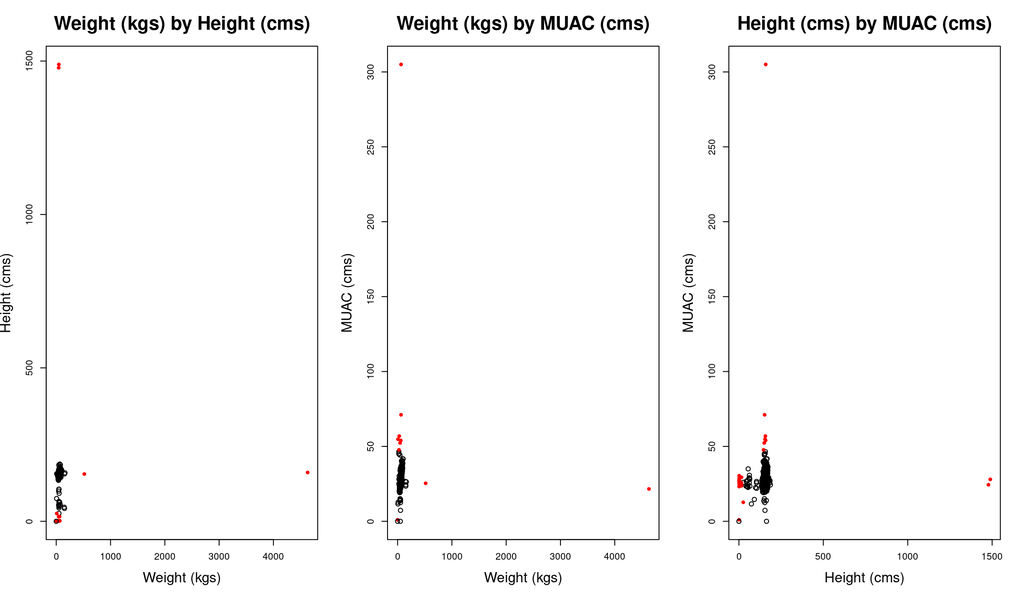

Number of outliers per bivariate comparison

| Outlier type | Number of records |
| --- | --- |
| Weight by height outlier | 27 |
| Weight by MUAC outlier | 10 |
| Height by MUAC outlier | 32 |

#### A total of **34** unique bivariate outliers were found and listed below. Potential outlier anthropometic measurements are in **BOLD RED**.

Outliers based on statistical distance

| Survey Date | Record ID | Survey Team | Enum Code | Weight (kgs) | Height (cms) | MUAC (cms) |
| --- | --- | --- | --- | --- | --- | --- |
| 2022-04-14 | 95735902 | 1 | 101 | 62 | 15.5 | 29.4 |
| 2022-04-14 | 95774098 | 11 | 1101 | 50.3 | 1.51 | 26.9 |
| 2022-04-14 | 95774210 | 11 | 1101 | 46.5 | 1.52 | 25.1 |
| 2022-04-15 | 95767982 | 7 | 701 | 55.4 | 1.65 | 28.5 |
| 2022-04-15 | 95767985 | 7 | 701 | 49.5 | 1.59 | 25.4 |
| 2022-04-15 | 95774398 | 11 | 1101 | 53.9 | 1.5 | 30.4 |
| 2022-04-16 | 95760411 | 5 | 503 | 47.1 | 1.52 | 23.2 |
| 2022-04-16 | 95760421 | 6 | 606 | 51.1 | 1.48 | 26 |
| 2022-04-16 | 95767990 | 7 | 701 | 61.2 | 1.58 | 27.5 |
| 2022-04-16 | 95767991 | 7 | 701 | 57.2 | 1.58 | 27.4 |
| 2022-04-16 | 95767992 | 7 | 701 | 44 | 1.59 | 23.4 |
| 2022-04-16 | 95767994 | 7 | 701 | 59.3 | 1.65 | 26.5 |
| 2022-04-18 | 95801799 | 11 | 1103 | 56 | 1.54 | 26.6 |
| 2022-04-18 | 95849374 | 12 | 1205 | 54.4 | 1.62 | 25.6 |
| 2022-04-18 | 95849376 | 12 | 1205 | 62.4 | 1.7 | 27.8 |
| 2022-04-18 | 95858687 | 7 | 701 | 46.1 | 1.5 | 26 |
| 2022-04-19 | 95848276 | 5 | 503 | 517 | 154.1 | 25.4 |
| 2022-04-19 | 95848324 | 6 | 606 | 44.8 | 1478 | 24.4 |
| 2022-04-20 | 95897258 | 12 | 1205 | 50.7 | 1.55 | 25.1 |
| 2022-04-21 | 95984135 | 2 | 205 | 59.2 | 158.2 | 54 |
| 2022-04-22 | 95997815 | 14 | 1405 | 64 | 152.4 | 71.1 |
| 2022-04-26 | 96190252 | 9 | 903 | 30.6 | 156.9 | 56.9 |
| 2022-05-01 | 96363980 | 3 | 301 | 47.5 | 1489 | 28 |
| 2022-05-02 | 96380106 | 9 | 903 | 48.4 | 15.7 | 23.7 |
| 2022-05-06 | 96516578 | 5 | 501 | 65.6 | 1.62 | 30.3 |
| 2022-05-08 | 96559919 | 3 | 301 | 4630 | 159.1 | 21.6 |
| 2022-05-08 | 96600438 | 8 | 805 | 46.9 | 1 | 27 |
| 2022-05-09 | 96596604 | 14 | 1406 | 64.6 | 158.8 | 305 |
| 2022-05-16 | 97469950 | 4 | 405 | 9.8 | 25.6 | 12.7 |
| 2022-05-17 | 97638005 | 4 | 405 | 44 | 15.1 | 25.7 |
| 2022-05-20 | 97832715 | 8 | 805 | 1 | 1 | 1 |
| 2022-05-22 | 98037118 | 4 | 405 | 26.2 | 146.2 | 47.7 |
| 2022-05-23 | 98192178 | 2 | 205 | 46.6 | 150 | 52.3 |
| 2022-05-25 | 98281840 | 5 | 501 | 8 | 154.9 | 54.8 |

#### A total of **342** unique outliers for mother anthropometric data were found. This is **8.3%** of the total dataset.

## 2.2. Child anthropometry

### 2.2.1. Check range and legal values

#### Univariate

The boxplots below show the identified outliers for weight, height, and MUAC measurements.

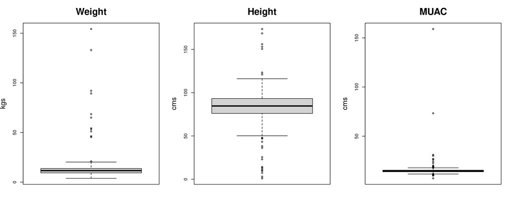

Outlier values for weight, height, and MUAC

The number of outliers for each measurement are:

Number of outliers per measurement type

| Outlier type | Number of records |
| --- | --- |
| Weight outlier | 18 |
| Height outlier | 23 |
| MUAC outlier | 64 |

#### A total of **90** unique univariate outliers were found and listed below. Potential outlier anthropometric measurements are in **BOLD RED**.

Outlier measurements - children

| Survey Date | Record ID | Survey Team | Enum Code | Weight (kgs) | Height (cms) | MUAC (cms) | Age (months) | Flagged in ODK |
| --- | --- | --- | --- | --- | --- | --- | --- | --- |
| 2022-04-13 | 95802965 | 14 | 1406 | 10.3 | 10.3 | 16 | 17 | YES |
| 2022-04-13 | 95992000 | 2 | 206 | 6.9 | 38.2 | 12 | 18 | YES |
| 2022-04-15 | 95796800 | 11 | 1101 | 20.2 | 108.2 | 18.3 | 56 | NA |
| 2022-04-15 | 95731984 | 9 | 903 | 9.7 | 36.2 | 14.4 | 32 | YES |
| 2022-04-15 | 95760907 | 14 | 1405 | 12.9 | 25.5 | 15.5 | 48 | YES |
| 2022-04-15 | 95847543 | 12 | 1205 | 17.7 | 98.7 | 18.7 | 43 | NA |
| 2022-04-16 | 95760530 | 4 | 406 | 54.2 | 84 | 14 | 22 | YES |
| 2022-04-16 | 95777235 | 8 | 805 | 14.7 | 95.1 | 18.5 | 47 | NA |
| 2022-04-16 | 95893294 | 12 | 1205 | 5 | 55.7 | 10.3 | 8 | NA |
| 2022-04-18 | 95798734 | 3 | 301 | 20.8 | 110.2 | 17.5 | 58 | NA |
| 2022-04-18 | 95800452 | 4 | 405 | 154.2 | 98.7 | 15.1 | 47 | YES |
| 2022-04-18 | 95800917 | 6 | 606 | 89.3 | 9.8 | 14 | 32 | YES |
| 2022-04-18 | 95799953 | 4 | 406 | 7.8 | 14.1 | 13 | 12 | YES |
| 2022-04-18 | 95800924 | 6 | 606 | 6.1 | 64.1 | 10.8 | 11 | NA |
| 2022-04-18 | 95801230 | 5 | 503 | 11.3 | 95 | 159 | 37 | NA |
| 2022-04-18 | 95863074 | 12 | 1206 | 12.6 | 77.1 | 18.5 | 14 | NA |
| 2022-04-19 | 95860315 | 3 | 301 | 133 | 3 | 13.3 | 24 | YES |
| 2022-04-19 | 95848324 | 6 | 606 | 8.3 | 70.2 | 11.3 | 20 | NA |
| 2022-04-20 | 95938639 | 11 | 1103 | 20 | 108 | 17.3 | 44 | NA |
| 2022-04-20 | 96302183 | 11 | 1103 | 46.2 | 156 | 26.2 | 13 | YES |
| 2022-04-20 | 95909121 | 7 | 701 | 5.5 | 47 | 12.3 | 15 | YES |
| 2022-04-21 | 96023221 | 1 | 103 | 14.9 | 123.2 | 15.2 | 37 | YES |
| 2022-04-21 | 95939951 | 5 | 501 | 7.9 | 74.6 | 11.4 | 20 | NA |
| 2022-04-21 | 95951883 | 7 | 703 | 10.4 | 73 | 18.2 | 12 | NA |
| 2022-04-22 | 96076705 | 11 | 1101 | 3.8 | 47.8 | 13.2 | 13 | YES |
| 2022-04-22 | 95997803 | 14 | 1405 | 14.9 | 93.4 | 17.9 | 35 | NA |
| 2022-04-22 | 96036202 | 7 | 701 | 16.9 | 95 | 19 | 40 | NA |
| 2022-04-23 | 96014295 | 10 | 1005 | 20 | 109 | 15.4 | 51 | NA |
| 2022-04-23 | 96045812 | 12 | 1205 | 20.2 | 111.9 | 18 | 53 | NA |
| 2022-04-23 | 96014524 | 8 | 806 | 17.5 | 95.1 | 18.3 | 36 | NA |

[output cut: 60 more lines]

When measurements are adjusted using the re-measured values, we get:

Number of outliers per measurement type

| Outlier type | Number of records |
| --- | --- |
| Weight outlier | 2 |
| Height outlier | 5 |
| MUAC outlier | 6 |

#### A total of **12** unique outliers were found and listed below. Potential outlier anthropometric measurements are in **BOLD RED**.

Outlier measurements (adjusted) - children

| Survey Date | Record ID | Survey Team | Enum Code | Weight (kgs) | Height (cms) | MUAC (cms) | Age (months) | Flagged in ODK |
| --- | --- | --- | --- | --- | --- | --- | --- | --- |
| 2022-04-13 | 95992000 | 2 | 206 | 6.5 | 38.2 | 12 | 18 | YES |
| 2022-04-15 | 95731984 | 9 | 903 | 9.7 | 36.2 | 14.4 | 32 | YES |
| 2022-04-18 | 95799953 | 4 | 406 | 7.81 | 14.1 | 13.2 | 12 | YES |
| 2022-04-21 | 96023221 | 1 | 103 | 14.9 | 123.9 | 15.2 | 37 | YES |
| 2022-04-25 | 96080527 | 14 | 1405 | 92 | 13.2 | 15 | 36 | YES |
| 2022-04-27 | 96173966 | 5 | 501 | 5.6 | 53.6 | 0 | 17 | YES |
| 2022-05-08 | 96591597 | 12 | 1205 | 6.8 | 63.6 | 0 | 29 | YES |
| 2022-05-11 | 96672014 | 7 | 703 | 13.4 | 72.3 | 17.2 | 38 | YES |
| 2022-05-12 | 96786867 | 5 | 503 | 4 | 77.5 | 9.9 | 17 | YES |
| 2022-05-22 | 98031380 | 14 | 1404 | 9.3 | 63.5 | 0 | 19 | YES |
| 2022-05-25 | 98311614 | 11 | 1103 | 7.4 | 61.1 | 0 | 14 | YES |
| 2022-05-26 | 98308415 | 5 | 501 | 17.5 | 80.3 | 15 | 28 | YES |

#### Bivariate outliers

The scatterplots below identify various bivariate outliers.

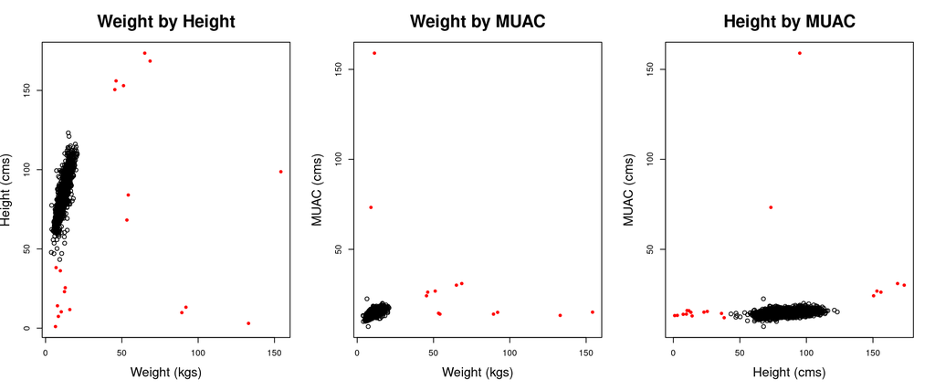

Bivariate outliers based on statistical distance

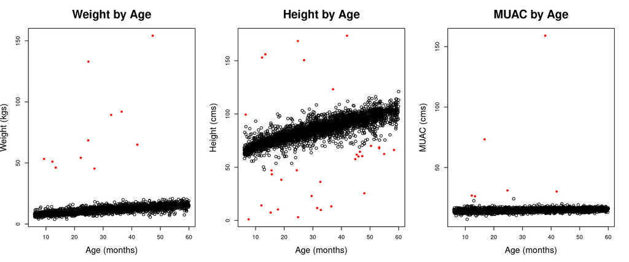

Bivariate outliers based on statistical distance

Following are the number of outliers identified per bivariate comparison.

Number of outliers per bivariate comparison

| Outlier type | Number of records |
| --- | --- |
| Weight by height outlier | 20 |
| Weight by MUAC outlier | 13 |
| Height by MUAC outlier | 19 |
| Weight by age outlier | 11 |
| Height by age outiler | 32 |
| MUAC by age outlier | 6 |

#### A total of **37** unique bivariate outliers are found and listed below. Potential outlier anthropometric measurements are in **BOLD RED**.

Bivariate outliers based on statistical distance

| Survey Date | Record ID | Survey Team | Enum Code | Weight (kgs) | Height (cms) | MUAC (cms) | Age (months) | Flagged in ODK |
| --- | --- | --- | --- | --- | --- | --- | --- | --- |
| 2022-04-13 | 95802965 | 14 | 1406 | 10.3 | 10.3 | 16 | 17 | YES |
| 2022-04-13 | 95992000 | 2 | 206 | 6.9 | 38.2 | 12 | 18 | YES |
| 2022-04-15 | 95731984 | 9 | 903 | 9.7 | 36.2 | 14.4 | 32 | YES |
| 2022-04-15 | 95760907 | 14 | 1405 | 12.9 | 25.5 | 15.5 | 48 | YES |
| 2022-04-16 | 95760530 | 4 | 406 | 54.2 | 84 | 14 | 22 | YES |
| 2022-04-18 | 95799953 | 4 | 406 | 7.8 | 14.1 | 13 | 12 | YES |
| 2022-04-18 | 95800452 | 4 | 405 | 154.2 | 98.7 | 15.1 | 47 | YES |
| 2022-04-18 | 95800917 | 6 | 606 | 89.3 | 9.8 | 14 | 32 | YES |
| 2022-04-18 | 95801230 | 5 | 503 | 11.3 | 95 | 159 | 37 | NA |
| 2022-04-19 | 95860315 | 3 | 301 | 133 | 3 | 13.3 | 24 | YES |
| 2022-04-19 | 95848316 | 6 | 606 | 7.2 | 99.4 | 12.4 | 6 | YES |
| 2022-04-20 | 96302183 | 11 | 1103 | 46.2 | 156 | 26.2 | 13 | YES |
| 2022-04-20 | 95909121 | 7 | 701 | 5.5 | 47 | 12.3 | 15 | YES |
| 2022-04-21 | 96023221 | 1 | 103 | 14.9 | 123.2 | 15.2 | 37 | YES |
| 2022-04-22 | 96045798 | 12 | 1205 | 7.9 | 62.4 | 15.2 | 54 | YES |
| 2022-04-25 | 96080527 | 14 | 1405 | 92 | 13.2 | 15 | 36 | YES |
| 2022-04-27 | 96204577 | 11 | 1101 | 7.5 | 66.2 | 14.3 | 58 | YES |
| 2022-04-28 | 96234369 | 3 | 303 | 8.4 | 7.4 | 13.9 | 15 | YES |
| 2022-04-28 | 96313898 | 11 | 1101 | 15.9 | 11.7 | 15.9 | 31 | YES |
| 2022-04-28 | 96228931 | 5 | 501 | 7.9 | 67.8 | 13.5 | 53 | YES |
| 2022-04-30 | 96301591 | 14 | 1405 | 6.5 | 1 | 13.2 | 7 | YES |
| 2022-04-30 | 96298964 | 5 | 501 | 7.2 | 60.1 | 14.4 | 45 | YES |
| 2022-05-01 | 96318912 | 11 | 1103 | 65 | 173.5 | 30.1 | 41 | YES |
| 2022-05-01 | 96363988 | 3 | 301 | 53.3 | 68.2 | 14.5 | 9 | YES |
| 2022-05-03 | 96515408 | 6 | 606 | 12.3 | 57.6 | 14.6 | 44 | YES |
| 2022-05-05 | 96599935 | 11 | 1103 | 7.1 | 68.7 | 12.4 | 53 | YES |
| 2022-05-06 | 96518393 | 3 | 301 | 12.4 | 23 | 15.1 | 29 | YES |
| 2022-05-06 | 96518356 | 4 | 406 | 14.2 | 61.8 | 15.1 | 45 | YES |
| 2022-05-08 | 96765371 | 11 | 1103 | 5.7 | 64.5 | 11.4 | 46 | YES |
| 2022-05-10 | 97350949 | 2 | 206 | 7.7 | 70 | 12.8 | 50 | YES |
| 2022-05-11 | 96792285 | 12 | 1206 | 9 | 73.3 | 73.3 | 16 | NA |
| 2022-05-13 | 96787961 | 13 | 1301 | 12.5 | 60.4 | 15.9 | 47 | YES |
| 2022-05-13 | 97469125 | 4 | 406 | 9.3 | 43.3 | 14.1 | 15 | YES |
| 2022-05-14 | 97157583 | 12 | 1205 | 51.1 | 153 | 26.8 | 12 | YES |
| 2022-05-14 | 97903759 | 12 | 1206 | 45.4 | 150.5 | 24.2 | 26 | YES |
| 2022-05-20 | 97775733 | 6 | 605 | 10.6 | 47.1 | 14.5 | 24 | YES |
| 2022-05-24 | 98311488 | 11 | 1103 | 68.5 | 168.5 | 31 | 24 | YES |

#### A total of **37 outliers** were found. This is **0.9%** of the full child anthropometric dataset.

### 2.2.2. Flagged records

The anthropometric z-scores are calculated using the [`{zscorer}`](https://nutriverse.io/zscorer). Values are then assessed based on the WHO flagging criteria and problematic values are flagged. For this, we only use the data from children 6-59 months old and we first calculate z-score using the first measurements.

This produces an updated anthropometric dataset that now includes calculated anthropometric z-scores (weight-for-age, height-for-age, and weight-for-height) and identifies flagged values based on WHO flagging criteria and indicates which anthropometric measurement is potentially problematic.

Following are the flagged records in the anthropometric dataset. Anthropometric measurements with potential issues are in **BOLD RED**.

Records with flagged anthropometric measurements based on WHO flagging criteria

| Survey Date | Record ID | Enum Code | Flag Description | Flagged in ODK | Weight (kgs) | Height (cms) | Age (months) |
| --- | --- | --- | --- | --- | --- | --- | --- |
| 2022-04-15 | 95731984 | 903 | Check height measurement | YES | 9.7 | 36.2 | 32 |
| 2022-04-16 | 95760530 | 406 | Check weight measurement | YES | 54.2 | 84 | 22 |
| 2022-04-15 | 95760907 | 1405 | Check height measurement | YES | 12.9 | 25.5 | 48 |
| 2022-04-16 | 95777239 | 805 | Check height and age measurements | YES | 8.8 | 73.5 | 47 |
| 2022-04-18 | 95799953 | 406 | Check height measurement | YES | 7.8 | 14.1 | 12 |
| 2022-04-18 | 95800452 | 405 | Check weight measurement | YES | 154.2 | 98.7 | 47 |
| 2022-04-18 | 95800915 | 606 | Check height and age measurements | YES | 7.7 | 70.2 | 33 |
| 2022-04-18 | 95800917 | 606 | Check age, height and weight measurements | YES | 89.3 | 9.8 | 32 |
| 2022-04-13 | 95802965 | 1406 | Check height measurement | YES | 10.3 | 10.3 | 17 |
| 2022-04-16 | 95809073 | 101 | Check weight and height measurements | YES | 14.2 | 69.2 | 27 |
| 2022-04-19 | 95848283 | 503 | Check height and age measurements | YES | 9.8 | 73.2 | 39 |
| 2022-04-19 | 95848316 | 606 | Check height measurement | YES | 7.2 | 99.4 | 6 |
| 2022-04-19 | 95853918 | 206 | Check height and age measurements | YES | 7.8 | 66.6 | 23 |
| 2022-04-19 | 95860315 | 301 | Check age, height and weight measurements | YES | 133 | 3 | 24 |
| 2022-04-19 | 95860326 | 301 | Check height measurement | YES | 12.5 | 53.6 | 22 |
| 2022-04-20 | 95898622 | 805 | Check height and age measurements | YES | 10.2 | 68.9 | 26 |
| 2022-04-20 | 95899749 | 206 | Check height and age measurements | YES | 12.2 | 73 | 43 |
| 2022-04-20 | 95905048 | 703 | Check height and age measurements | YES | 7.3 | 60.5 | 20 |
| 2022-04-20 | 95907008 | 606 | Check height and age measurements | YES | 7.5 | 55.8 | 9 |
| 2022-04-20 | 95907017 | 606 | Check height and age measurements | YES | 9.8 | 79.4 | 53 |
| 2022-04-20 | 95909121 | 701 | Check height measurement | YES | 5.5 | 47 | 15 |
| 2022-04-20 | 95952014 | 301 | Check height measurement | YES | 7.5 | 50.2 | 12 |
| 2022-04-21 | 95973431 | 701 | Check height and age measurements | YES | 9.8 | 72.3 | 48 |
| 2022-04-13 | 95992000 | 206 | Check height measurement | YES | 6.9 | 38.2 | 18 |
| 2022-04-22 | 95997813 | 1405 | Check height and age measurements | YES | 9.1 | 70.6 | 47 |
| 2022-04-23 | 96010507 | 501 | Check height and age measurements | YES | 7.8 | 71.7 | 44 |
| 2022-04-21 | 96023221 | 103 | Check height measurement | YES | 14.9 | 123.2 | 37 |
| 2022-04-22 | 96025254 | 206 | Check height and age measurements | YES | 11.9 | 69.3 | 40 |
| 2022-04-23 | 96038682 | 805 | Check height and age measurements | YES | 8.7 | 76.2 | 51 |
| 2022-04-22 | 96045798 | 1205 | Check height and age measurements | YES | 7.9 | 62.4 | 54 |

[output cut: 75 more lines]

A total of **105** records are identified. This is **2.8%** of the total records in the child anthropometric dataset.

Following are the flagged records in the anthropometric dataset after adjusting the measurements. Anthropometric measurements with potential issues are in **BOLD RED**.

Records with flagged anthropometric measurements based on WHO flagging criteria after measurement adjustment

| Survey Date | Record ID | Enum Code | Flag Description | Flagged in ODK | Weight (kgs) | Height (cms) | Age (months) |
| --- | --- | --- | --- | --- | --- | --- | --- |
| 2022-04-15 | 95731984 | 903 | Check height measurement | YES | 9.7 | 36.2 | 33 |
| 2022-04-16 | 95777239 | 805 | Check height and age measurements | YES | 8.8 | 73.5 | 47 |
| 2022-04-18 | 95799953 | 406 | Check height measurement | YES | 7.8 | 14.1 | 12 |
| 2022-04-18 | 95800915 | 606 | Check height and age measurements | YES | 7.7 | 70.2 | 33 |
| 2022-04-16 | 95809073 | 101 | Check weight and height measurements | YES | 14.2 | 69.2 | 27 |
| 2022-04-19 | 95848283 | 503 | Check height and age measurements | YES | 9.8 | 73.2 | 40 |
| 2022-04-19 | 95848316 | 606 | Check height measurement | YES | 7.2 | 99.4 | 7 |
| 2022-04-19 | 95853918 | 206 | Check height and age measurements | YES | 7.8 | 66.6 | 24 |
| 2022-04-20 | 95898622 | 805 | Check height and age measurements | YES | 10.2 | 68.9 | 27 |
| 2022-04-20 | 95899749 | 206 | Check height and age measurements | YES | 12.2 | 73 | 44 |
| 2022-04-20 | 95905048 | 703 | Check height and age measurements | YES | 7.3 | 60.5 | 20 |
| 2022-04-20 | 95907008 | 606 | Check height and age measurements | YES | 7.5 | 55.8 | 9 |
| 2022-04-20 | 95907017 | 606 | Check height and age measurements | YES | 9.8 | 79.4 | 54 |
| 2022-04-20 | 95909121 | 701 | Check height measurement | YES | 5.5 | 47 | 16 |
| 2022-04-21 | 95973431 | 701 | Check height and age measurements | YES | 9.8 | 72.3 | 48 |
| 2022-04-13 | 95992000 | 206 | Check height measurement | YES | 6.9 | 38.2 | 19 |
| 2022-04-22 | 95997813 | 1405 | Check height and age measurements | YES | 9.1 | 70.6 | 47 |
| 2022-04-23 | 96010507 | 501 | Check height and age measurements | YES | 7.8 | 71.7 | 44 |
| 2022-04-21 | 96023221 | 103 | Check height measurement | YES | 14.9 | 123.2 | 37 |
| 2022-04-22 | 96025254 | 206 | Check height and age measurements | YES | 11.9 | 69.3 | 40 |
| 2022-04-23 | 96038682 | 805 | Check height and age measurements | YES | 8.7 | 76.2 | 51 |
| 2022-04-22 | 96045798 | 1205 | Check height and age measurements | YES | 7.9 | 62.4 | 55 |
| 2022-04-22 | 96046283 | 205 | Check height and age measurements | YES | 8.4 | 69 | 39 |
| 2022-04-23 | 96046289 | 205 | Check height and age measurements | YES | 11.1 | 69.6 | 34 |
| 2022-04-25 | 96068750 | 805 | Check height and age measurements | YES | 9.5 | 67.2 | 29 |
| 2022-04-22 | 96076705 | 1101 | Check age measurement | YES | 3.8 | 47.8 | 13 |
| 2022-04-25 | 96080431 | 901 | Check height and age measurements | YES | 6.3 | 62.4 | 20 |
| 2022-04-25 | 96080527 | 1405 | Check age, height and weight measurements | YES | 92 | 13.2 | 36 |
| 2022-04-26 | 96117091 | 501 | Check height and age measurements | YES | 7.9 | 60 | 17 |
| 2022-04-25 | 96169401 | 301 | Check height and age measurements | YES | 8.1 | 68.9 | 46 |
| 2022-04-27 | 96173966 | 501 | Check height and age measurements | YES | 5.6 | 53.6 | 17 |
| 2022-04-20 | 96190613 | 1103 | Check height and age measurements | YES | 12.8 | 86.2 | 8 |
| 2022-04-27 | 96204577 | 1101 | Check height and age measurements | YES | 7.5 | 66.2 | 58 |
| 2022-04-28 | 96228931 | 501 | Check height and age measurements | YES | 7.9 | 67.8 | 53 |
| 2022-04-28 | 96229697 | 503 | Check height and age measurements | YES | 7.8 | 65.8 | 19 |
| 2022-04-25 | 96273945 | 1206 | Check height measurement | YES | 8.9 | 59 | 24 |
| 2022-04-30 | 96298957 | 501 | Check weight and height measurements | YES | 8.9 | 57.9 | 10 |
| 2022-04-30 | 96298964 | 501 | Check height and age measurements | YES | 7.2 | 60.1 | 46 |
| 2022-04-29 | 96354014 | 206 | Check height and age measurements | YES | 7.9 | 59 | 18 |
| 2022-04-28 | 96359940 | 1206 | Check height and age measurements | YES | 15.4 | 98.2 | 18 |
| 2022-05-03 | 96373112 | 503 | Check height and age measurements | YES | 6.7 | 60 | 20 |
| 2022-05-02 | 96389913 | 205 | Check height and age measurements | YES | 14.3 | 99.9 | 18 |
| 2022-05-05 | 96461217 | 606 | Check height and age measurements | YES | 9.9 | 74.3 | 45 |
| 2022-04-29 | 96500632 | 1206 | Check height and age measurements | YES | 9.9 | 75.2 | 48 |
| 2022-05-07 | 96541228 | 503 | Check height and age measurements | YES | 7.9 | 71.9 | 48 |
| 2022-05-09 | 96590456 | 503 | Check height measurement | YES | 10.3 | 60.2 | 21 |
| 2022-05-08 | 96591597 | 1205 | Check height and age measurements | YES | 6.8 | 63.6 | 29 |
| 2022-05-05 | 96599935 | 1103 | Check height and age measurements | YES | 7.1 | 68.7 | 53 |
| 2022-05-10 | 96632642 | 605 | Check height and age measurements | YES | 6.7 | 66.2 | 27 |
| 2022-05-11 | 96672014 | 703 | Check height and age measurements | YES | 13.4 | 72.3 | 38 |
| 2022-05-12 | 96754488 | 605 | Check weight and height measurements | YES | 8.5 | 95.7 | 21 |
| 2022-05-11 | 96755125 | 503 | Check height and age measurements | YES | 9.7 | 70.3 | 28 |
| 2022-05-08 | 96765371 | 1103 | Check age measurement | YES | 5.7 | 64.5 | 46 |
| 2022-05-12 | 96786774 | 606 | Check height and age measurements | YES | 9.9 | 71.7 | 39 |
| 2022-05-12 | 96786867 | 503 | Check weight measurement | YES | 4 | 77.5 | 17 |
| 2022-05-10 | 97021049 | 605 | Check weight and height measurements | YES | 9.2 | 99.5 | 33 |
| 2022-05-14 | 97124900 | 805 | Check height and age measurements | YES | 9.3 | 76 | 49 |
| 2022-05-11 | 97125029 | 301 | Check height and age measurements | YES | 12.3 | 93.2 | 10 |
| 2022-05-13 | 97125167 | 301 | Check height and age measurements | YES | 11.4 | 82.7 | 6 |
| 2022-05-14 | 97134231 | 701 | Check height and age measurements | YES | 8.5 | 75.5 | 53 |
| 2022-05-14 | 97134236 | 701 | Check height and age measurements | YES | 10.4 | 64.1 | 24 |
| 2022-05-10 | 97222383 | 205 | Check height and age measurements | YES | 11 | 76.9 | 52 |
| 2022-05-10 | 97350949 | 206 | Check height and age measurements | YES | 7.7 | 70 | 50 |
| 2022-05-14 | 97469948 | 405 | Check height and age measurements | YES | 7.5 | 64.6 | 21 |
| 2022-05-18 | 97645022 | 206 | Check height and age measurements | YES | 8.9 | 75.5 | 55 |
| 2022-05-18 | 97682690 | 605 | Check height and age measurements | YES | 7.3 | 81.1 | 7 |
| 2022-05-20 | 97861463 | 206 | Check height and age measurements | YES | 10.9 | 72.5 | 43 |
| 2022-05-22 | 97986052 | 503 | Check height and age measurements | YES | 8.7 | 70 | 28 |
| 2022-05-21 | 97998240 | 206 | Check height and age measurements | YES | 8.5 | 67.9 | 31 |
| 2022-05-22 | 98031380 | 1404 | Check height and age measurements | YES | 9.3 | 63.5 | 20 |
| 2022-05-23 | 98084830 | 503 | Check height and age measurements | YES | 9.5 | 70.1 | 28 |
| 2022-05-23 | 98192164 | 205 | Check weight and height measurements | YES | 9.2 | 95 | 40 |
| 2022-05-25 | 98285382 | 1405 | Check height and age measurements | YES | 11.7 | 88.1 | 7 |
| 2022-05-26 | 98308415 | 501 | Check weight and height measurements | YES | 17.5 | 80.3 | 28 |
| 2022-05-25 | 98311614 | 1103 | Check height and age measurements | YES | 7.4 | 61.1 | 15 |

A total of **75 child records** were flagged. This is **2.0%** of the total records in the child anthropometric dataset.

### 2.2.3. Distribution of anthropometric z-scores and MUAC

Removing outliers and flagged anthropometric measurements, we observe the distribution of the anthropometric z-scores and MUAC as follows:

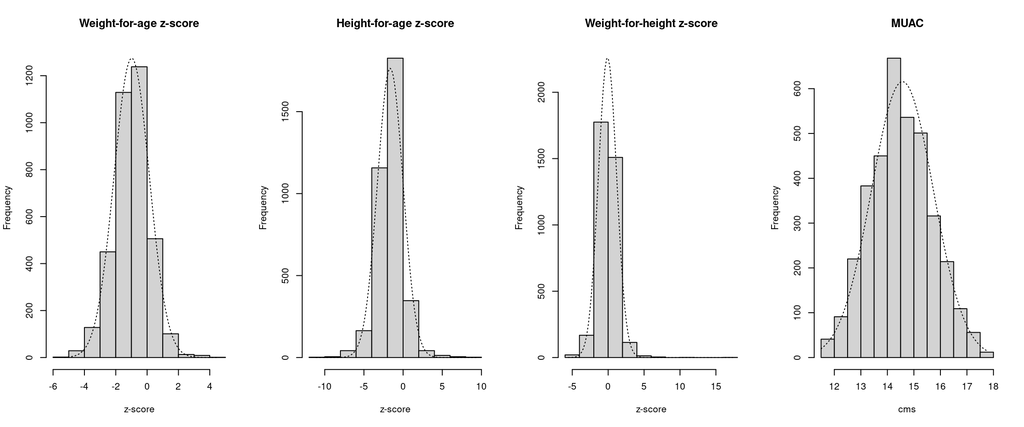

Distribution of anthropometric z-score values and MUAC

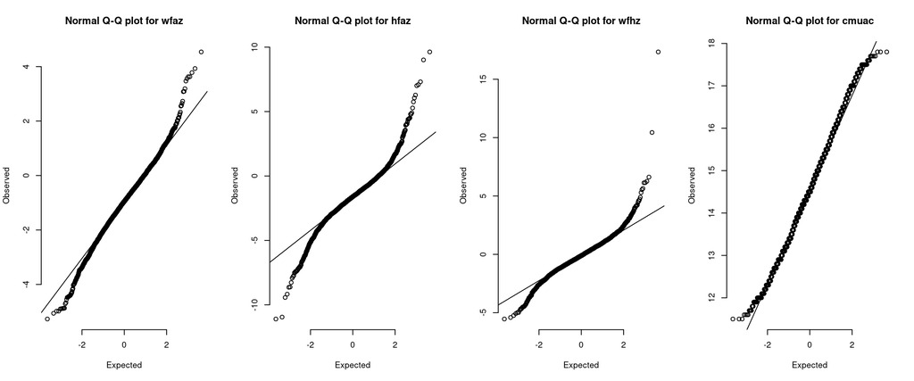

Quantile-quantile plots of anthropometric z-score values and MUAC

#### **Skewness and Kurtosis**

Checking for skewness and kurtosis on child anthropometric data, the following are observed:

**Skewness and kurtosis of weight-for-age z-score**

```
##
##  Skewness and kurtosis
##
## Skewness = +13.5494  SE = 0.0402 z = 336.9241    p = 0.0000
## Kurtosis = +309.4393 SE = 0.0804 z = 3848.3424   p = 0.0000
```

The skewness of weight-for-age z-score distribution is **14**. This is **problematic**.

The kurtosis of weight-for-age z-score distribution is **309**. This is **problematic**.

**Skewness and kurtosis of height-for-age z-score**

```
##
##  Skewness and kurtosis
##
## Skewness = -0.2171   SE = 0.0402 z = 5.3972  p = 0.0000
## Kurtosis = +53.4364  SE = 0.0804 z = 664.4724    p = 0.0000
```

The skewness of height-for-age z-score distribution is **0**. This is **good**.

The kurtosis of height-for-age z-score distribution is **53**. This is **problematic**.

**Skewness and kurtosis of weight-for-height z-score**

```
##
##  Skewness and kurtosis
##
## Skewness = +17.3840  SE = 0.0403 z = 431.0500    p = 0.0000
## Kurtosis = +541.2231 SE = 0.0806 z = 6711.8546   p = 0.0000
```

The skewness of weight-for-height z-score distribution is **17**. This is **problematic**.

The kurtosis of weight-for-height z-score distribution is **541**. This is **problematic**.

Checking for skewness and kurtosis on child anthropometric data where outliers and flagged values have been removed, the following are observed:

**Skewness and kurtosis of weight-for-age z-score - without outliers and flagged values**

```
##
##  Skewness and kurtosis
##
## Skewness = -0.0843   SE = 0.0404 z = 2.0845  p = 0.0371
## Kurtosis = +0.9654   SE = 0.0809 z = 11.9393 p = 0.0000
```

The skewness of weight-for-age z-score distribution is **0**. This is **excellent**.

The kurtosis of weight-for-age z-score distribution is **1**. This is **problematic**.

**Skewness and kurtosis of height-for-age z-score - without outliers and flagged values**

```
##
##  Skewness and kurtosis
##
## Skewness = +0.0702   SE = 0.0404 z = 1.7365  p = 0.0825
## Kurtosis = +4.1936   SE = 0.0809 z = 51.8580 p = 0.0000
```

The skewness of height-for-age z-score distribution is **0**. This is **excellent**.

The kurtosis of height-for-age z-score distribution is **4**. This is **problematic**.

**Skewness and kurtosis of weight-for-height z-score - without outliers and flagged values**

```
##
##  Skewness and kurtosis
##
## Skewness = +0.8990   SE = 0.0404 z = 22.2276 p = 0.0000
## Kurtosis = +11.9736  SE = 0.0809 z = 148.0644    p = 0.0000
```

The skewness of weight-for-height z-score distribution is **1**. This is **problematic**.

The kurtosis of weight-for-height z-score distribution is **12**. This is **problematic**.

### 2.2.4. Median absolute deviation of weight-for-height z-score

The median absolute deviation (MAD) for weight-for-height z-score is **1.089711**. This is **within the 0.8 to 1.2 range recommended.**.

### Check Benford’s Law

#### Weight-for-age z-score

```
## Chi-square =  194.9509   df =  8     p =  1
```

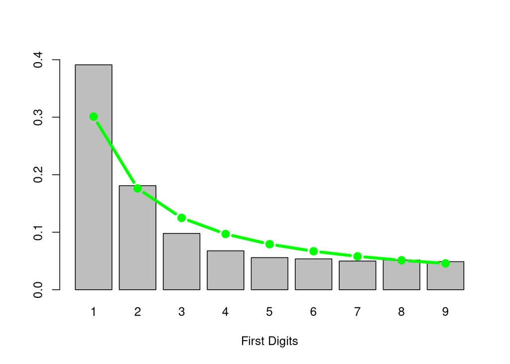

#### Height-for-age z-score

```
## Chi-square =  376.6916   df =  8     p =  1
```

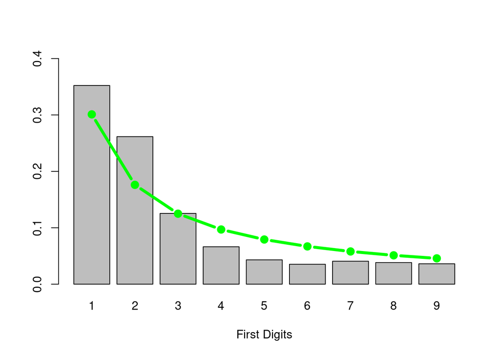

#### Weight-for-height z-score

```
## Chi-square =  121.9603   df =  8     p =  1
```

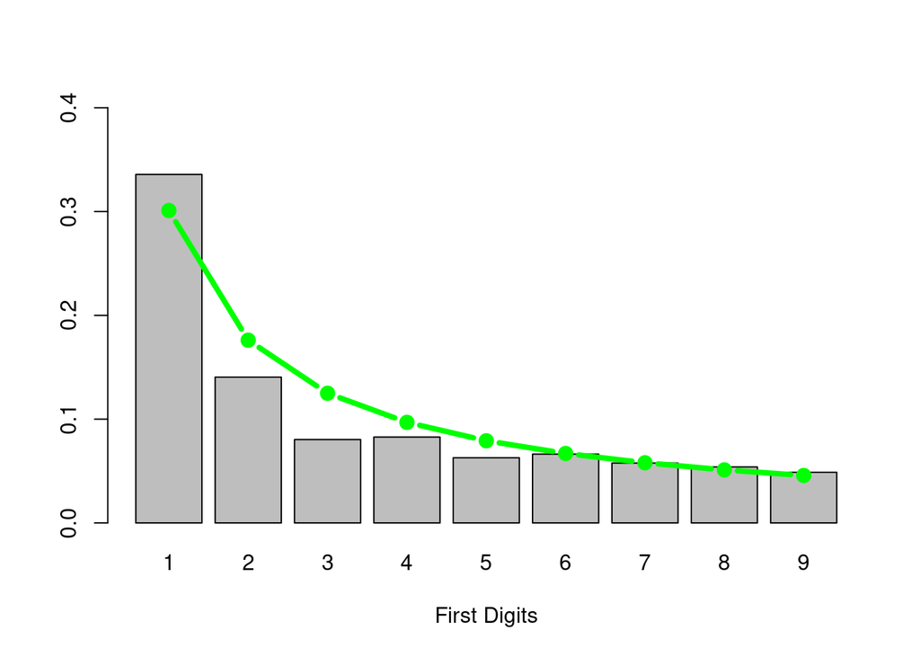

### 2.2.5. Digit preference

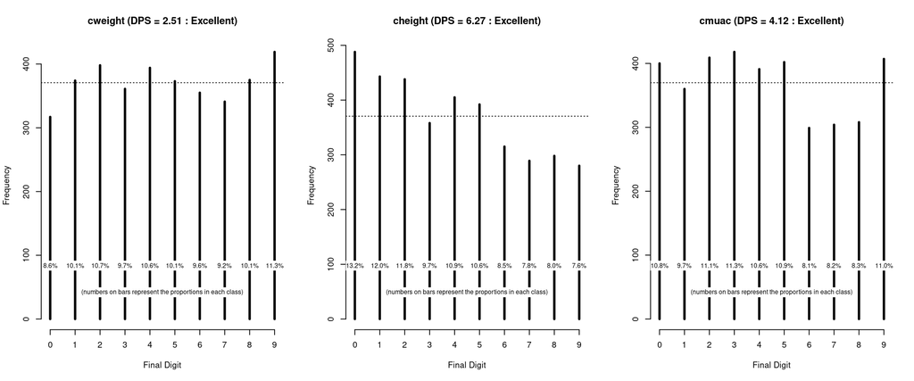

Digit preference scores and plots for weight, height and MUAC

The **digit preference score for weight** is **2.51**. This digit preference score is **Excellent**.

The **digit preference score for height** is **6.27**. This digit preference score is **Excellent**.

The **digit preference score for MUAC** is **4.12**. This digit preference score is **Excellent**.

### 2.2.6. Age heaping

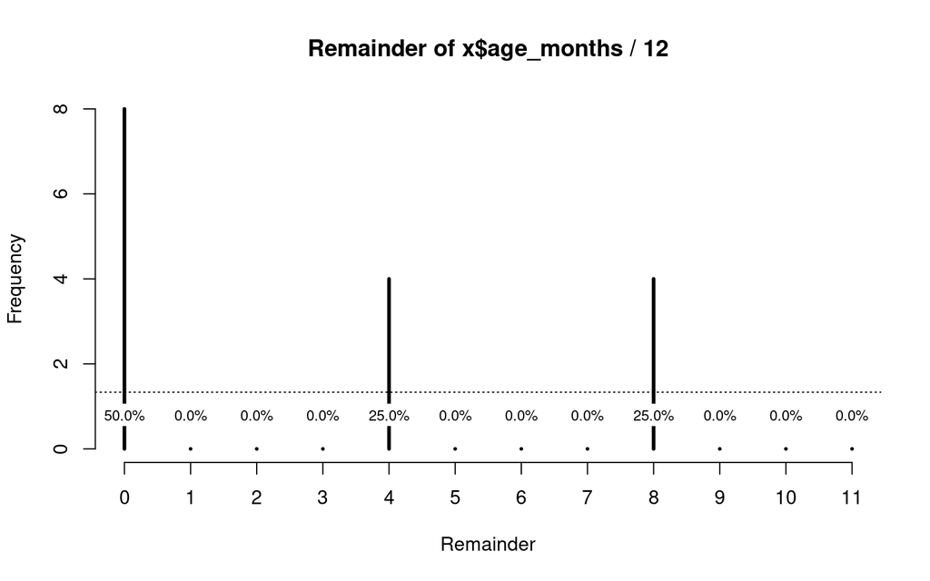

Plot assessing age heaping in the anthropometric dataset

```
##
##  Age-heaping Analysis
##
## data:    Remainder of x$age_months / 12
## X-squared = 56, df = 11, p-value = 0.0000
```

There is **significant age heaping at whole years** in the child anthropometric dataset.

### 2.2.7. Sex ratio

The sex ratio in the anthropometric dataset is compared against the expected sex ratio of children under 5 years old in Mozambique which is 1.03 males for every female (from the [United States Census Bureau’s International Data Base](https://www.census.gov/data-tools/demo/idb/#/pop?COUNTRY_YEAR=2018&COUNTRY_YR_ANIM=2018&FIPS_SINGLE=MZ&menu=popViz&POP_YEARS=2018&quickReports=OVW&popPages=BYAGE&FIPS=MZ&ageGroup=5Y)).

```
##
##  Sex Ratio Test
##
## Expected proportion male = 0.5074
## Observed proportion male = 0.5081
## X-squared = 0.0062, p = 0.9375
```

The ratio of boys and girls in the data is **not significantly different from the ratio of boys and girls in the general population** in Mozambique.

### 2.2.8. Age ratio

```
##
##      Age Ratio Test (children's data)
##
##                     Expected age ratio = 0.8500
## Expected proportion aged 6 - 29 months = 0.4595
##
##                     Observed age ratio = 0.9025
## Observed proportion aged 6 - 29 months = 0.4744
##
## X-squared = 3.2639, p = 0.0708
```

The age ratio in the child anthropometric dataset is **not significantly different from the expected age ratio of 0.85**.

### 2.2.9. Age structure

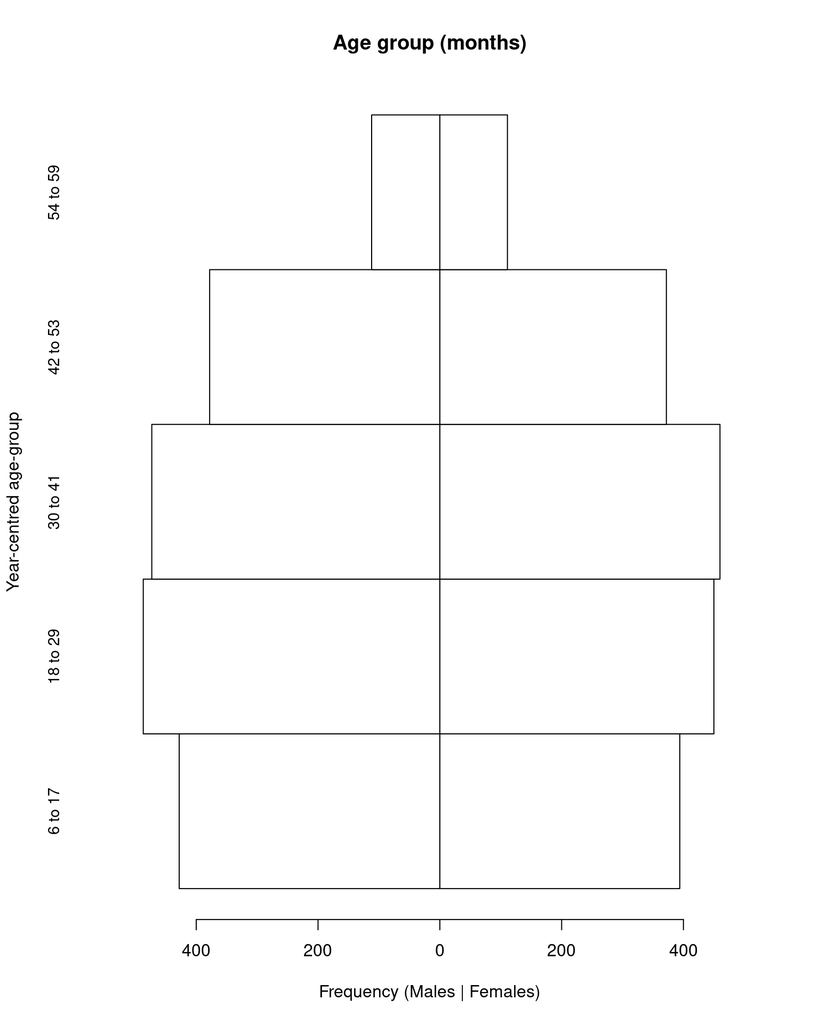

Age structure of the under 5 sample